# Coastal wetland valuation

Daniel Hewitt, Matt Taylor, Rod Connolly

25/07/2022

# 1 Introduction

Coastal wetlands act as nursery habitats for several commercially and recreationally exploited species of fish and crustaceans (Beck *et al.*, 2001; Dahlgren *et al.*, 2006).

# 2 Fisheries enhancement via resource provisioning

Taylor *et al.* (2018) provide an established framework to estimate the value of coastal wetlands (e.g., mangroves, saltmarsh) on the basis of their contribution to the diet of exploited species via the following formula:

$$\begin{equation}
GVP_{s,p} = C_{s,p}\cdot H_s\cdot M_s\cdot P_s
\tag{2.1}
\end{equation}$$

where *GVP<sub>s, p</sub>* is the gross value of production (AUD y<sup>-1</sup>) of species *s* derived from primary producer *p*, *C<sub>s, p</sub>* is the proportional contribution of primary producer *p* for species *s* derived from stable isotope measurements and associated modelling, *H<sub>s</sub>* is the annual harvest of species *s* (kg y<sup>-1</sup>), *M<sub>s</sub>* is the market value for species *s* (AUD kg<sup>-1</sup>), and *P<sub>s</sub>* is the spatial partitioning coefficient for species *s* (see Taylor *et al.* (2018) for further details).

## 2.1 Estimating economic value

Estimation of economic value is achieved by determining the gross value of production (GVP), based on market value at first-point-of-sale (FPS). GVP is then converted to total economic output (TOP) via an economic multiplier (*m*; derived from data presented in Voyer *et al.*, 2016). The multiplier *m* is expressed using a normal distribution (i.e., $m \sim N[\mu, \sigma]$), derived from the statewide-GVP for New South Wales (*P<sub>GV</sub>*), and the minimum (*O<sub>min</sub>*) and maximum (*O<sub>max</sub>*) estimate of total economic output from commercial fishing (including GVP, and the value of retail processing etc.) reported in Voyer *et al.* (2016), using the two following equations:

$$\begin{equation}
\sigma = \frac{\frac{O_{max}-O_{min}}{P_{GV}}}{6}
\tag{2.2}
\end{equation}$$

$$\begin{equation}
\mu = \frac{O_{max}}{P_{GV}}-3\sigma
\tag{2.3}
\end{equation}$$

# 3 Fisheries enhancement via nursery services

## 3.1 Estimating species abundance

Enhancement (*E*) of the exploited species (*s*) by habitat (*h*) is calculated for each species using the following equation:

$$\begin{equation}
E_{s,e} = (P_{s, h} - P_{s,u})
\tag{3.1}
\end{equation}$$

where *P<sub>s, h</sub>* is the abundance of juveniles (estimated to be 0.5 years old) of species *s* in habitat *h* (individuals ha<sup>-1</sup>), and *P<sub>s, u</sub>* is the abundance of species *s* in unvegetated habitats *u* (Zu Ermgassen *et al.*, 2016; Jänes *et al.*, 2020).

## 3.2 Estimating species biomass

Total average annual biomass production of each exploited species *s* supported by habitat *h* (kg ha<sup>-1</sup> y<sup>-1</sup>) is estimated using the approach developed by Peterson *et al.* (2003) and extended by Zu Ermgassen *et al.* (2016). This approach incorporates species-specific natural mortality (*M*), but not fishing mortality, via the following equation:

$$\begin{equation}
y_{s,i} = e^{-Mi}
\tag{3.2}
\end{equation}$$

where *y<sub>s</sub>* is the proportion of exploited species *s* surviving to age class *i*. Biomass enhancement (kg ha<sup>-1</sup>) for each age class (*B<sub>i</sub>*) is then calculated by:

$$\begin{equation}
B_i = E_{s,e}\cdot e^{-M\cdot(i-0.5)}
\tag{3.3}
\end{equation}$$

where *E<sub>s,e</sub>* is taken from Equation (3.1). For each age class *i*, the length of an average individual (total length [TL] for teleosts, carapace length [CL] for crustaceans) was calculated using the Lorenzen (2000) growth equation and subsequently converted to weight (biomass, kg) using length-weight relationships. The total annual biomass enhancement (kg ha<sup>-1</sup>) of species *s* was then calculated by summing the incremental increase in biomass for an average individual in each year class *i* by the number/density (ha<sup>-1</sup>) of species *s* (*B<sub>i</sub>*) in each age class.

# 4 Example of code chunks

## 4.1 Generate normal observations

```r
x <- rnorm(n = 100, mean = 0, sd = 1)
```

## 4.2 Take the mean

```r
mean(x)
```

```
## [1] -0.01107776
```

## 4.3 Plot a histogram

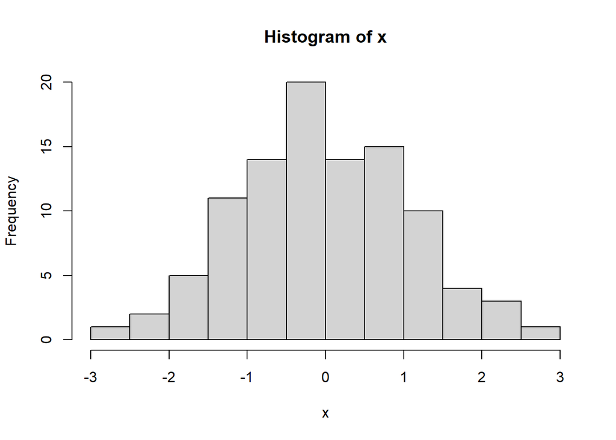

```r
hist(x)
```

# References

Beck, M.W., Heck, K.L., Able, K.W., Childers, D.L., Eggleston, D.B., Gillanders, B.M., Halpern, B., Hays, C.G., Hoshino, K., Minello, T.J., Orth, R.J., Sheridan, P.F. and Weinstein, M.P. (2001) The identification, conservation, and management of estuarine and marine nurseries for fish and invertebrates, *BioScience*, 51(8), pp. 633–641. https://doi.org/10.1641/0006-3568(2001)051[0633:Ticamo]2.0.Co;2.

Dahlgren, C.P., Kellison, G.T., Adams, A.J., Gillanders, B.M., Kendall, M.S., Layman, C.A., Ley, J.A., Nagelkerken, I. and Serafy, J.E. (2006) Marine nurseries and effective juvenile habitats: Concepts and applications, *Marine Ecology Progress Series*, 312, pp. 291–295. https://doi.org/10.3354/meps312291.

Jänes, H., Macreadie, P.I., Zu Ermgassen, P.S.E., Gair, J.R., Treby, S., Reeves, S., Nicholson, E., Ierodiaconou, D. and Carnell, P. (2020) Quantifying fisheries enhancement from coastal vegetated ecosystems, *Ecosystem Services*, 43, p. 101105. https://doi.org/10.1016/j.ecoser.2020.101105.

Lorenzen, K. (2000) Allometry of natural mortality as a basis for assessing optimal release size in fish-stocking programmes, *Canadian Journal of Fisheries and Aquatic Sciences*, 57(12), pp. 2374–2381.

Peterson, C.H., Grabowski, J.H. and Powers, S.P. (2003) Estimated enhancement of fish production resulting from restoring oyster reef habitat: Quantitative valuation, *Marine Ecology Progress Series*, 264, pp. 249–264.

Taylor, M.D., Gaston, T.F. and Raoult, V. (2018) The economic value of fisheries harvest supported by saltmarsh and mangrove productivity in two australian estuaries, *Ecological Indicators*, 84, pp. 701–709. https://doi.org/10.1016/j.ecolind.2017.08.044.

Voyer, M., Barclay, K., Mcllgorm, A. and Mazur, N. (2016) *Social and economic evaluation of NSW coastal professional wild-catch fisheries: Valuing coastal fisheries*. Fisheries Research; Development Corporation.

Zu Ermgassen, P.S., Grabowski, J.H., Gair, J.R. and Powers, S.P. (2016) Quantifying fish and mobile invertebrate production from a threatened nursery habitat, *Journal of Applied Ecology*, 53(2), pp. 596–606.